# Project 2

For this project, I decided to use the Kaggle dataset for Life Expectancy Data from World Health Organization. This Dataset contains many statstics about a country's lifestyle as well as their disease statstics. There are 193 countries represented in this dataset. There are 2938 rows and 22 columns. Some questions I have interested in is:

1. What are the countries with the lowest Polio Immunization rates?
2. Out of Measles, Polio and Diphtheria, which disease has the most normal distribution when compared to Immunization Percentage?
3. Is there any correlation between GDP and Expenditure %?

```python
## import packages:
import random # library of function for generating random numbers and samples
import numpy as np # for vector operations
import pandas as pd # for Data Frame methods
import matplotlib.pyplot as plt # Two dimensional plotting library
import seaborn as sns
from scipy import stats #  library of statistical functions
import sklearn #

#
# Set seed for generating psuedo random numbers
np.random.seed(12345678)
#
# Set up graphics
plt.style.use('classic')
%matplotlib inline
```

# Importing Libraries

```python
import os
print(os.getcwd())
```

```
C:\Users\Jeffo\Downloads\New folder
```

```python
#df = pd.read_csv("Life Expectancy Data.csv", index_col=0)
#df.columns #check columns to see if there are any unnamed variables
data = pd.read_csv('Life Expectancy Data.csv', delimiter=',')
data.dataframeName = 'Life Expectancy Data.csv'
```

# Glimpse at the Data

```python
data.head()
```

|  | Country | Year | Status | Life expectancy | Adult Mortality | infant deaths | Alcohol | percentage expenditure | Hepatitis B | Measles | ... | Polio | Total expenditure | Diphtheria | HIV/AIDS | GDP | Population | thinness 1-19 years | thinness 5-9 years | Income composition of resources | Schooling |
| --- | --- | --- | --- | --- | --- | --- | --- | --- | --- | --- | --- | --- | --- | --- | --- | --- | --- | --- | --- | --- | --- |
| 0 | Afghanistan | 2015 | Developing | 65.0 | 263.0 | 62 | 0.01 | 71.279624 | 65.0 | 1154 | ... | 6.0 | 8.16 | 65.0 | 0.1 | 584.259210 | 33736494.0 | 17.2 | 17.3 | 0.479 | 10.1 |
| 1 | Afghanistan | 2014 | Developing | 59.9 | 271.0 | 64 | 0.01 | 73.523582 | 62.0 | 492 | ... | 58.0 | 8.18 | 62.0 | 0.1 | 612.696514 | 327582.0 | 17.5 | 17.5 | 0.476 | 10.0 |
| 2 | Afghanistan | 2013 | Developing | 59.9 | 268.0 | 66 | 0.01 | 73.219243 | 64.0 | 430 | ... | 62.0 | 8.13 | 64.0 | 0.1 | 631.744976 | 31731688.0 | 17.7 | 17.7 | 0.470 | 9.9 |
| 3 | Afghanistan | 2012 | Developing | 59.5 | 272.0 | 69 | 0.01 | 78.184215 | 67.0 | 2787 | ... | 67.0 | 8.52 | 67.0 | 0.1 | 669.959000 | 3696958.0 | 17.9 | 18.0 | 0.463 | 9.8 |
| 4 | Afghanistan | 2011 | Developing | 59.2 | 275.0 | 71 | 0.01 | 7.097109 | 68.0 | 3013 | ... | 68.0 | 7.87 | 68.0 | 0.1 | 63.537231 | 2978599.0 | 18.2 | 18.2 | 0.454 | 9.5 |

5 rows × 22 columns

```python
data.count()
```

```
Country                            2938
Year                               2938
Status                             2938
Life expectancy                    2928
Adult Mortality                    2928
infant deaths                      2938
Alcohol                            2744
percentage expenditure             2938
Hepatitis B                        2385
Measles                            2938
 BMI                               2904
under-five deaths                  2938
Polio                              2919
Total expenditure                  2712
Diphtheria                         2919
 HIV/AIDS                          2938
GDP                                2490
Population                         2286
 thinness  1-19 years              2904
 thinness 5-9 years                2904
Income composition of resources    2771
Schooling                          2775
dtype: int64
```

```python
data.median()
```

```
Year                               2.008000e+03
Life expectancy                    7.210000e+01
Adult Mortality                    1.440000e+02
infant deaths                      3.000000e+00
Alcohol                            3.755000e+00
percentage expenditure             6.491291e+01
Hepatitis B                        9.200000e+01
Measles                            1.700000e+01
 BMI                               4.350000e+01
under-five deaths                  4.000000e+00
Polio                              9.300000e+01
Total expenditure                  5.755000e+00
Diphtheria                         9.300000e+01
 HIV/AIDS                          1.000000e-01
GDP                                1.766948e+03
Population                         1.386542e+06
 thinness  1-19 years              3.300000e+00
 thinness 5-9 years                3.300000e+00
Income composition of resources    6.770000e-01
Schooling                          1.230000e+01
dtype: float64
```

## Organizing the data

```python
data.columns = data.columns.str.replace(' ','')
```

```python
df1= data.loc[data['Country'].isin(['Zimbabwe','Sudan', 'Uganda','Tonga','Togo'])]
```

```python
df1.head()
df1
```

|  | Country | Year | Status | Life expectancy | Adult Mortality | infant deaths | Alcohol | percentage expenditure | Hepatitis B | Measles | ... | Polio | Total expenditure | Diphtheria | HIV/AIDS | GDP | Population | thinness 1-19 years | thinness 5-9 years | Income composition of resources | Schooling |
| --- | --- | --- | --- | --- | --- | --- | --- | --- | --- | --- | --- | --- | --- | --- | --- | --- | --- | --- | --- | --- | --- |
| 2457 | Sudan | 2015 | Developing | 64.1 | 225.0 | 58 | NaN | 0.000000 | 93.0 | 3585 | ... | 93.0 | NaN | 93.0 | 0.3 | 2513.884661 | 3864783.0 | NaN | NaN | 0.488 | 7.2 |
| 2458 | Sudan | 2014 | Developing | 63.8 | 229.0 | 59 | 0.01 | 253.608651 | 94.0 | 676 | ... | 94.0 | 8.43 | 94.0 | 0.3 | 2176.898290 | 37737913.0 | NaN | NaN | 0.485 | 7.2 |
| 2459 | Sudan | 2013 | Developing | 63.5 | 232.0 | 60 | 0.01 | 227.835321 | 93.0 | 2813 | ... | 93.0 | 8.42 | 93.0 | 0.3 | 1955.667990 | 36849918.0 | NaN | NaN | 0.478 | 7.0 |
| 2460 | Sudan | 2012 | Developing | 63.2 | 235.0 | 61 | 0.01 | 220.522192 | 92.0 | 8523 | ... | 92.0 | 8.20 | 92.0 | 0.3 | 1892.894352 | 3599192.0 | NaN | NaN | 0.468 | 6.8 |
| 2461 | Sudan | 2011 | Developing | 62.7 | 241.0 | 61 | 2.12 | 196.689215 | 93.0 | 5616 | ... | 93.0 | 8.30 | 93.0 | 0.3 | 1666.857757 | 35167314.0 | NaN | NaN | 0.463 | 7.0 |
| 2462 | Sudan | 2010 | Developing | 62.5 | 243.0 | 62 | 1.77 | 172.009788 | 75.0 | 680 | ... | 9.0 | 7.97 | 9.0 | 0.3 | 1476.478870 | 34385963.0 | NaN | NaN | 0.461 | 7.0 |
| 2463 | Sudan | 2009 | Developing | 62.0 | 248.0 | 63 | 1.99 | 17.053693 | 72.0 | 68 | ... | 81.0 | 8.40 | 81.0 | 0.3 | 1226.884381 | 3365619.0 | NaN | NaN | 0.456 | 6.8 |
| 2464 | Sudan | 2008 | Developing | 61.8 | 251.0 | 64 | 2.01 | 128.636271 | 78.0 | 129 | ... | 85.0 | 8.17 | 86.0 | 0.3 | 1291.528826 | 32955496.0 | NaN | NaN | 0.444 | 6.3 |
| 2465 | Sudan | 2007 | Developing | 61.4 | 254.0 | 65 | 2.01 | 86.131669 | 78.0 | 327 | ... | 84.0 | 4.72 | 84.0 | 0.3 | 1115.695200 | 32282526.0 | NaN | NaN | 0.440 | 6.4 |
| 2466 | Sudan | 2006 | Developing | 61.0 | 26.0 | 66 | 1.90 | 60.336857 | 6.0 | 228 | ... | 77.0 | 3.93 | 78.0 | 0.2 | 893.879364 | 316764.0 | NaN | NaN | 0.430 | 6.2 |
| 2467 | Sudan | 2005 | Developing | 67.0 | 261.0 | 66 | 1.55 | 37.590396 | 22.0 | 1374 | ... | 78.0 | 3.18 | 78.0 | 0.2 | 679.753995 | 3911914.0 | NaN | NaN | 0.423 | 6.1 |
| 2468 | Sudan | 2004 | Developing | 59.7 | 278.0 | 68 | 1.59 | 37.044800 | NaN | 9562 | ... | 74.0 | 3.39 | 74.0 | 0.2 | 565.569459 | 3186341.0 | NaN | NaN | 0.415 | 5.7 |
| 2469 | Sudan | 2003 | Developing | 59.6 | 278.0 | 69 | 1.74 | 35.352647 | NaN | 4381 | ... | 69.0 | 3.18 | 69.0 | 0.2 | 477.738478 | 29435944.0 | NaN | NaN | 0.409 | 5.6 |
| 2470 | Sudan | 2002 | Developing | 59.4 | 277.0 | 70 | 1.59 | 30.622875 | NaN | 4529 | ... | 6.0 | 2.95 | 6.0 | 0.2 | 412.151756 | 28679565.0 | NaN | NaN | 0.403 | 5.6 |
| 2471 | Sudan | 2001 | Developing | 58.9 | 283.0 | 71 | 1.81 | 28.880697 | NaN | 4362 | ... | 66.0 | 2.96 | 66.0 | 0.2 | 377.525445 | 279455.0 | NaN | NaN | 0.399 | 5.6 |
| 2472 | Sudan | 2000 | Developing | 58.6 | 284.0 | 71 | 1.76 | 30.860010 | NaN | 2875 | ... | 62.0 | 3.23 | 62.0 | 0.1 | 361.358430 | 2725535.0 | NaN | NaN | 0.394 | 5.5 |
| 2617 | Togo | 2015 | Developing | 59.9 | 287.0 | 13 | NaN | 0.000000 | 88.0 | 20 | ... | 88.0 | NaN | 88.0 | 1.0 | 551.138346 | 741682.0 | 6.5 | 6.2 | 0.484 | 12.0 |
| 2618 | Togo | 2014 | Developing | 59.7 | 285.0 | 13 | 0.01 | 4.877350 | 87.0 | 577 | ... | 85.0 | 5.25 | 87.0 | 1.0 | 62.131849 | 7228915.0 | 6.6 | 6.4 | 0.475 | 12.0 |
| 2619 | Togo | 2013 | Developing | 59.4 | 287.0 | 14 | 0.01 | 48.730471 | 84.0 | 564 | ... | 84.0 | 5.12 | 84.0 | 1.5 | 579.434850 | 742948.0 | 6.8 | 6.6 | 0.470 | 12.0 |
| 2620 | Togo | 2012 | Developing | 58.9 | 294.0 | 14 | 0.01 | 41.600280 | 84.0 | 238 | ... | 84.0 | 5.11 | 84.0 | 1.7 | 563.689425 | 6859482.0 | 7.0 | 6.8 | 0.464 | 12.0 |
| 2621 | Togo | 2011 | Developing | 58.3 | 34.0 | 14 | 1.44 | 39.082585 | 85.0 | 187 | ... | 85.0 | 5.21 | 85.0 | 2.6 | 562.339359 | 6679282.0 | 7.1 | 7.0 | 0.457 | 11.5 |
| 2622 | Togo | 2010 | Developing | 57.4 | 323.0 | 14 | 1.21 | 41.961455 | 83.0 | 120 | ... | 83.0 | 5.37 | 83.0 | 3.8 | 487.923891 | 652952.0 | 7.3 | 7.2 | 0.449 | 11.0 |
| 2623 | Togo | 2009 | Developing | 56.7 | 336.0 | 14 | 1.24 | 77.095512 | 78.0 | 425 | ... | 78.0 | 6.64 | 78.0 | 4.3 | 499.646871 | 633472.0 | 7.5 | 7.4 | 0.442 | 10.6 |
| 2624 | Togo | 2008 | Developing | 56.2 | 344.0 | 14 | 1.33 | 69.359248 | 24.0 | 187 | ... | 8.0 | 5.73 | 81.0 | 4.8 | 513.391914 | 6161796.0 | 7.7 | 7.6 | 0.441 | 10.1 |
| 2625 | Togo | 2007 | Developing | 55.9 | 344.0 | 14 | 1.37 | 0.675683 | NaN | 8 | ... | 72.0 | 5.55 | 82.0 | 5.1 | 42.764743 | 5997385.0 | 7.9 | 7.8 | 0.443 | 10.6 |
| 2626 | Togo | 2006 | Developing | 55.7 | 345.0 | 15 | 1.37 | 6.226049 | NaN | 26 | ... | 85.0 | 5.56 | 84.0 | 5.0 | 377.336290 | 5837792.0 | 8.1 | 8.0 | 0.436 | 10.2 |
| 2627 | Togo | 2005 | Developing | 55.0 | 357.0 | 15 | 1.14 | 36.621743 | NaN | 38 | ... | 8.0 | 5.17 | 82.0 | 5.0 | 372.172184 | 5683268.0 | 8.4 | 8.3 | 0.435 | 10.1 |
| 2628 | Togo | 2004 | Developing | 54.9 | 355.0 | 15 | 1.01 | 3.989928 | NaN | 61 | ... | 71.0 | 5.60 | 71.0 | 5.1 | 349.993725 | 5534598.0 | 8.6 | 8.5 | 0.432 | 10.0 |
| 2629 | Togo | 2003 | Developing | 54.7 | 355.0 | 15 | 1.02 | 2.995960 | NaN | 295 | ... | 72.0 | 5.00 | 72.0 | 5.2 | 31.437144 | 539141.0 | 8.8 | 8.7 | 0.428 | 9.9 |
| 2630 | Togo | 2002 | Developing | 54.7 | 351.0 | 15 | 1.00 | 1.995183 | NaN | 363 | ... | 58.0 | 4.70 | 59.0 | 5.3 | 28.832123 | 5251472.0 | 9.0 | 8.9 | 0.428 | 9.7 |
| ... | ... | ... | ... | ... | ... | ... | ... | ... | ... | ... | ... | ... | ... | ... | ... | ... | ... | ... | ... | ... | ... |
| 2716 | Uganda | 2013 | Developing | 67.0 | 325.0 | 71 | 0.01 | 90.761444 | 78.0 | 7878 | ... | 82.0 | 7.47 | 78.0 | 4.0 | 662.492293 | 37553726.0 | 5.7 | 5.7 | 0.478 | 10.0 |
| 2717 | Uganda | 2012 | Developing | 60.0 | 339.0 | 73 | 0.01 | 92.886979 | 78.0 | 2027 | ... | 82.0 | 7.58 | 78.0 | 4.6 | 647.747410 | 3636796.0 | 5.8 | 5.8 | 0.477 | 10.0 |
| 2718 | Uganda | 2011 | Developing | 59.3 | 347.0 | 76 | 10.22 | 94.496868 | 82.0 | 3312 | ... | 82.0 | 9.90 | 82.0 | 6.8 | 584.396214 | 3593648.0 | 5.9 | 5.9 | 0.477 | 10.7 |
| 2719 | Uganda | 2010 | Developing | 58.4 | 362.0 | 79 | 10.03 | 116.202964 | 8.0 | 1313 | ... | 79.0 | 11.20 | 8.0 | 8.0 | 594.997256 | 33915133.0 | 6.0 | 6.0 | 0.473 | 10.9 |
| 2720 | Uganda | 2009 | Developing | 57.5 | 378.0 | 82 | 9.63 | 87.045350 | 79.0 | 1601 | ... | 78.0 | 8.43 | 79.0 | 8.1 | 647.177320 | 32771895.0 | 6.1 | 6.1 | 0.464 | 10.8 |
| 2721 | Uganda | 2008 | Developing | 56.3 | 41.0 | 84 | 9.79 | 72.850237 | 71.0 | 1319 | ... | 69.0 | 9.10 | 71.0 | 8.2 | 449.692818 | 31663896.0 | 6.2 | 6.2 | 0.453 | 10.6 |
| 2722 | Uganda | 2007 | Developing | 55.5 | 41.0 | 88 | 9.65 | 6.002528 | 73.0 | 3776 | ... | 7.0 | 9.76 | 73.0 | 8.4 | 41.858631 | 359487.0 | 6.3 | 6.3 | 0.442 | 10.3 |
| 2723 | Uganda | 2006 | Developing | 54.9 | 41.0 | 93 | 9.81 | 50.839014 | 64.0 | 5736 | ... | 62.0 | 9.86 | 64.0 | 8.6 | 336.459392 | 2955662.0 | 6.4 | 6.4 | 0.434 | 10.6 |
| 2724 | Uganda | 2005 | Developing | 53.2 | 446.0 | 99 | 10.09 | 44.526140 | 64.0 | 22 | ... | 59.0 | 9.36 | 64.0 | 8.7 | 315.788227 | 2854394.0 | 6.5 | 6.5 | 0.429 | 10.9 |
| 2725 | Uganda | 2004 | Developing | 51.3 | 485.0 | 104 | 9.89 | 36.606093 | 62.0 | 141 | ... | 58.0 | 8.90 | 62.0 | 8.9 | 288.236949 | 27568436.0 | 6.6 | 6.6 | 0.427 | 11.6 |
| 2726 | Uganda | 2003 | Developing | 51.0 | 53.0 | 109 | 10.16 | 4.426792 | 44.0 | 29429 | ... | 57.0 | 7.54 | 59.0 | 9.4 | 237.999592 | 2662482.0 | 6.7 | 6.7 | 0.418 | 11.5 |
| 2727 | Uganda | 2002 | Developing | 48.8 | 523.0 | 112 | 10.42 | 2.690898 | 29.0 | 49871 | ... | 57.0 | 7.78 | 57.0 | 10.0 | 24.242323 | 2571848.0 | 6.8 | 6.8 | 0.404 | 11.0 |
| 2728 | Uganda | 2001 | Developing | 47.7 | 539.0 | 115 | 10.57 | 26.976252 | NaN | 48543 | ... | 56.0 | 7.26 | 55.0 | 10.8 | 234.984775 | 24854892.0 | 6.9 | 6.9 | 0.396 | 10.8 |
| 2729 | Uganda | 2000 | Developing | 46.6 | 554.0 | 116 | 10.47 | 22.594475 | NaN | 42554 | ... | 55.0 | 6.77 | 52.0 | 11.6 | 257.633690 | 2439274.0 | 7.0 | 7.0 | 0.382 | 9.8 |
| 2922 | Zimbabwe | 2015 | Developing | 67.0 | 336.0 | 22 | NaN | 0.000000 | 87.0 | 0 | ... | 88.0 | NaN | 87.0 | 6.2 | 118.693830 | 15777451.0 | 5.6 | 5.5 | 0.507 | 10.3 |
| 2923 | Zimbabwe | 2014 | Developing | 59.2 | 371.0 | 23 | 6.50 | 10.822595 | 91.0 | 0 | ... | 92.0 | 6.44 | 91.0 | 6.3 | 127.474620 | 15411675.0 | 5.9 | 5.7 | 0.498 | 10.3 |
| 2924 | Zimbabwe | 2013 | Developing | 58.0 | 399.0 | 25 | 6.39 | 10.666707 | 95.0 | 0 | ... | 95.0 | 6.88 | 95.0 | 6.8 | 111.227396 | 155456.0 | 6.2 | 6.0 | 0.488 | 10.4 |
| 2925 | Zimbabwe | 2012 | Developing | 56.6 | 429.0 | 26 | 6.09 | 92.602336 | 97.0 | 0 | ... | 95.0 | 6.69 | 95.0 | 8.8 | 955.648466 | 1471826.0 | 6.5 | 6.4 | 0.464 | 9.8 |
| 2926 | Zimbabwe | 2011 | Developing | 54.9 | 464.0 | 28 | 6.00 | 63.750530 | 94.0 | 0 | ... | 93.0 | 6.31 | 93.0 | 13.3 | 839.927936 | 14386649.0 | 6.8 | 6.7 | 0.452 | 10.1 |
| 2927 | Zimbabwe | 2010 | Developing | 52.4 | 527.0 | 29 | 5.21 | 53.308581 | 9.0 | 9696 | ... | 89.0 | 5.37 | 89.0 | 15.7 | 713.635620 | 1486317.0 | 7.1 | 7.0 | 0.436 | 10.0 |
| 2928 | Zimbabwe | 2009 | Developing | 50.0 | 587.0 | 30 | 4.64 | 1.040021 | 73.0 | 853 | ... | 69.0 | 6.26 | 73.0 | 18.1 | 65.824121 | 1381599.0 | 7.5 | 7.4 | 0.419 | 9.9 |
| 2929 | Zimbabwe | 2008 | Developing | 48.2 | 632.0 | 30 | 3.56 | 20.843429 | 75.0 | 0 | ... | 75.0 | 4.96 | 75.0 | 20.5 | 325.678573 | 13558469.0 | 7.8 | 7.8 | 0.421 | 9.7 |
| 2930 | Zimbabwe | 2007 | Developing | 46.6 | 67.0 | 29 | 3.88 | 29.814566 | 72.0 | 242 | ... | 73.0 | 4.47 | 73.0 | 23.7 | 396.998217 | 1332999.0 | 8.2 | 8.2 | 0.414 | 9.6 |
| 2931 | Zimbabwe | 2006 | Developing | 45.4 | 7.0 | 28 | 4.57 | 34.262169 | 68.0 | 212 | ... | 71.0 | 5.12 | 7.0 | 26.8 | 414.796232 | 13124267.0 | 8.6 | 8.6 | 0.408 | 9.5 |
| 2932 | Zimbabwe | 2005 | Developing | 44.6 | 717.0 | 28 | 4.14 | 8.717409 | 65.0 | 420 | ... | 69.0 | 6.44 | 68.0 | 30.3 | 444.765750 | 129432.0 | 9.0 | 9.0 | 0.406 | 9.3 |
| 2933 | Zimbabwe | 2004 | Developing | 44.3 | 723.0 | 27 | 4.36 | 0.000000 | 68.0 | 31 | ... | 67.0 | 7.13 | 65.0 | 33.6 | 454.366654 | 12777511.0 | 9.4 | 9.4 | 0.407 | 9.2 |
| 2934 | Zimbabwe | 2003 | Developing | 44.5 | 715.0 | 26 | 4.06 | 0.000000 | 7.0 | 998 | ... | 7.0 | 6.52 | 68.0 | 36.7 | 453.351155 | 12633897.0 | 9.8 | 9.9 | 0.418 | 9.5 |
| 2935 | Zimbabwe | 2002 | Developing | 44.8 | 73.0 | 25 | 4.43 | 0.000000 | 73.0 | 304 | ... | 73.0 | 6.53 | 71.0 | 39.8 | 57.348340 | 125525.0 | 1.2 | 1.3 | 0.427 | 10.0 |
| 2936 | Zimbabwe | 2001 | Developing | 45.3 | 686.0 | 25 | 1.72 | 0.000000 | 76.0 | 529 | ... | 76.0 | 6.16 | 75.0 | 42.1 | 548.587312 | 12366165.0 | 1.6 | 1.7 | 0.427 | 9.8 |
| 2937 | Zimbabwe | 2000 | Developing | 46.0 | 665.0 | 24 | 1.68 | 0.000000 | 79.0 | 1483 | ... | 78.0 | 7.10 | 78.0 | 43.5 | 547.358879 | 12222251.0 | 11.0 | 11.2 | 0.434 | 9.8 |

80 rows × 22 columns

```python
print(df1.index) #print the number of indexes in the dataframe
print(df1.columns) #print each column in the dataframes
```

```
Int64Index([2457, 2458, 2459, 2460, 2461, 2462, 2463, 2464, 2465, 2466, 2467,
            2468, 2469, 2470, 2471, 2472, 2617, 2618, 2619, 2620, 2621, 2622,
            2623, 2624, 2625, 2626, 2627, 2628, 2629, 2630, 2631, 2632, 2633,
            2634, 2635, 2636, 2637, 2638, 2639, 2640, 2641, 2642, 2643, 2644,
            2645, 2646, 2647, 2648, 2714, 2715, 2716, 2717, 2718, 2719, 2720,
            2721, 2722, 2723, 2724, 2725, 2726, 2727, 2728, 2729, 2922, 2923,
            2924, 2925, 2926, 2927, 2928, 2929, 2930, 2931, 2932, 2933, 2934,
            2935, 2936, 2937],
           dtype='int64')
Index(['Country', 'Year', 'Status', 'Life expectancy ', 'Adult Mortality',
       'infant deaths', 'Alcohol', 'percentage expenditure', 'Hepatitis B',
       'Measles ', ' BMI ', 'under-five deaths ', 'Polio', 'Total expenditure',
       'Diphtheria ', ' HIV/AIDS', 'GDP', 'Population',
       ' thinness  1-19 years', ' thinness 5-9 years',
       'Income composition of resources', 'Schooling'],
      dtype='object')
```

```python
df1.info()
```

[output not shown]

## Plots

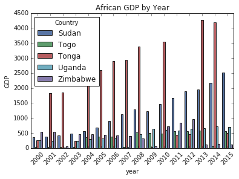

```python
barplot = sns.barplot( x=df1["Year"], y=df1["GDP"], hue=df1["Country"] )

barplot.set(xlabel="year",ylabel="GDP",title="African GDP by Year")
plt.xticks(rotation=45)
```

[figure not shown]

```python
plt.figure(figsize=(8,14))
sns.set(style="ticks")

plt.subplot(3,1,1)
plot1 = sns.distplot(df1['Measles'],color='green')
plot1.set_xlabel("Measles",fontsize=14)
plot1.set_ylabel("Immunization Coverage Percentage",fontsize=14)
plot1.set_title("Immunization for Measles, Polio and Diphtheria",fontsize=14)

plt.subplot(3,1,2)
plot2 = sns.distplot(df1['Polio'],color='b')
plot2.set_xlabel("Polio",fontsize=14)
plot2.set_ylabel("Immunization Coverage Percentage",fontsize=14)

plt.subplot(3,1,3)
plot3 = sns.distplot(df1['Diphtheria'],color='orange')
plot3.set_xlabel("Diphtheria",fontsize=14)
plot3.set_ylabel("Immunization Coverage Percentage",fontsize=14)

plt.show()
```

```python
dd = data.groupby('Country').mean().nsmallest(10,'Polio').reset_index()
dd
```

|  | Country | Year | Lifeexpectancy | AdultMortality | infantdeaths | Alcohol | percentageexpenditure | HepatitisB | Measles | BMI | ... | Polio | Totalexpenditure | Diphtheria | HIV/AIDS | GDP | Population | thinness1-19years | thinness5-9years | Incomecompositionofresources | Schooling |
| --- | --- | --- | --- | --- | --- | --- | --- | --- | --- | --- | --- | --- | --- | --- | --- | --- | --- | --- | --- | --- | --- |
| 0 | Equatorial Guinea | 2014.0 | 57.900000 | 32.000000 | 3.000000 | 0.010000 | 13.404774 | 2.000000 | 13.000000 | 24.000000 | ... | 24.000000 | 3.800000 | 2.000000 | 4.400000 | 192.597330 | 1.129424e+06 | 8.500000 | 8.400000 | 0.582000 | 9.200000 |
| 1 | Chad | 2011.0 | 52.285714 | 322.142857 | 46.000000 | 0.464286 | 44.437289 | 27.571429 | 1527.571429 | 17.500000 | ... | 31.857143 | 3.198571 | 27.857143 | 3.814286 | 712.233898 | 7.677455e+06 | 9.214286 | 9.100000 | 0.367000 | 6.800000 |
| 2 | Central African Republic | 2011.5 | 51.416667 | 444.833333 | 16.166667 | 0.820000 | 42.604459 | 41.833333 | 273.166667 | 14.933333 | ... | 42.500000 | 3.808333 | 41.833333 | 5.733333 | 431.961740 | 3.072260e+06 | 8.750000 | 8.700000 | 0.356500 | 6.850000 |
| 3 | Ethiopia | 2010.5 | 62.737500 | 228.000000 | 160.625000 | 1.216250 | 55.425268 | 62.500000 | 4495.250000 | 15.837500 | ... | 44.250000 | 5.328750 | 57.625000 | 1.625000 | 342.074425 | 5.689150e+07 | 6.412500 | 2.775000 | 0.403625 | 8.037500 |
| 4 | Nigeria | 2009.5 | 52.840000 | 340.200000 | 523.700000 | 8.177000 | 122.423682 | 42.300000 | 21896.400000 | 20.150000 | ... | 45.600000 | 3.831000 | 43.700000 | 4.750000 | 1675.523082 | 5.459305e+07 | 8.800000 | 8.710000 | 0.490800 | 9.410000 |
| 5 | Afghanistan | 2007.5 | 58.193750 | 269.062500 | 78.250000 | 0.014375 | 34.960110 | 64.562500 | 2362.250000 | 15.518750 | ... | 48.375000 | 8.252500 | 52.312500 | 0.100000 | 340.015425 | 9.972260e+06 | 16.581250 | 15.581250 | 0.415375 | 8.212500 |
| 6 | Guinea | 2010.5 | 57.712500 | 194.625000 | 28.625000 | 0.128750 | 22.249983 | 59.250000 | 80.750000 | 16.512500 | ... | 50.500000 | 4.582500 | 53.625000 | 1.825000 | 311.268858 | 3.288246e+06 | 8.137500 | 8.100000 | 0.386250 | 8.237500 |
| 7 | Iraq | 2009.0 | 70.390909 | 135.727273 | 31.545455 | 0.130000 | 175.510821 | 65.545455 | 4456.636364 | 55.172727 | ... | 53.363636 | 4.442727 | 68.727273 | 0.100000 | 3412.401922 | 1.478780e+07 | 5.354545 | 5.118182 | 0.640636 | 10.236364 |
| 8 | Samoa | 2007.0 | 73.593333 | 134.133333 | 0.000000 | 2.704000 | 271.570153 | 54.666667 | 0.600000 | 62.120000 | ... | 57.000000 | 5.325333 | 62.733333 | 0.100000 | 1986.437795 | 1.272855e+05 | 0.200000 | 0.173333 | 0.676867 | 12.626667 |
| 9 | Niger | 2011.5 | 61.350000 | 239.666667 | 49.666667 | 0.068333 | 18.055959 | 59.833333 | 763.666667 | 17.900000 | ... | 57.333333 | 6.305000 | 59.833333 | 0.750000 | 319.388894 | 1.488506e+07 | 4.383333 | 4.216667 | 0.326500 | 4.866667 |

10 rows × 21 columns

[output not shown]

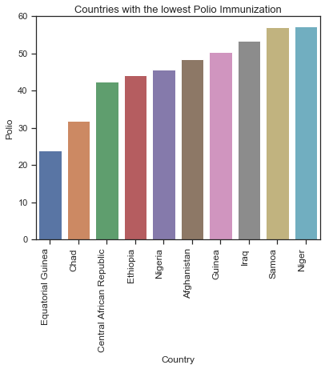

```python
plt.figure(figsize=(14,5))


plt.subplot(1,2,1)
plot1 = sns.barplot(data=dd,x=dd.Country,y=dd['Polio'])
plot1.set_title("Countries with the lowest Polio Immunization",fontsize=13)
plot1.set_xticklabels(plot1.get_xticklabels(), rotation=90, ha="right", fontsize=12)
```

# Finding Correlation

```python
df1.corr()
```

|  | Year | Life expectancy | Adult Mortality | infant deaths | Alcohol | percentage expenditure | Hepatitis B | Measles | BMI | under-five deaths | Polio | Total expenditure | Diphtheria | HIV/AIDS | GDP | Population | thinness 1-19 years | thinness 5-9 years | Income composition of resources | Schooling |
| --- | --- | --- | --- | --- | --- | --- | --- | --- | --- | --- | --- | --- | --- | --- | --- | --- | --- | --- | --- | --- |
| Year | 1.000000 | 0.050771 | -0.037092 | 0.008029 | -0.113365 | 0.069553 | 0.114897 | -0.053822 | 0.005739 | 0.010479 | -0.016699 | 0.059493 | 0.029641 | -0.123405 | 0.096421 | 0.012567 | 0.019757 | 0.014122 | 0.122892 | 0.088732 |
| Life expectancy | 0.050771 | 1.000000 | -0.702523 | -0.169074 | 0.402718 | 0.409631 | 0.199935 | -0.068881 | 0.542042 | -0.192265 | 0.327294 | 0.174718 | 0.341331 | -0.592236 | 0.441322 | -0.022305 | -0.457838 | -0.457508 | 0.721083 | 0.727630 |
| Adult Mortality | -0.037092 | -0.702523 | 1.000000 | 0.042450 | -0.175535 | -0.237610 | -0.105225 | -0.003967 | -0.351542 | 0.060365 | -0.199853 | -0.085227 | -0.191429 | 0.550691 | -0.255035 | -0.015012 | 0.272230 | 0.286723 | -0.442203 | -0.421171 |
| infant deaths | 0.008029 | -0.169074 | 0.042450 | 1.000000 | -0.106217 | -0.090765 | -0.231769 | 0.532680 | -0.234425 | 0.996906 | -0.156929 | -0.146951 | -0.161871 | 0.007712 | -0.098092 | 0.671758 | 0.463415 | 0.461908 | -0.134754 | -0.214372 |
| Alcohol | -0.113365 | 0.402718 | -0.175535 | -0.106217 | 1.000000 | 0.417047 | 0.109889 | -0.050110 | 0.353396 | -0.101082 | 0.240315 | 0.214885 | 0.242951 | -0.027113 | 0.443433 | -0.028880 | -0.403755 | -0.386208 | 0.561074 | 0.616975 |
| percentage expenditure | 0.069553 | 0.409631 | -0.237610 | -0.090765 | 0.417047 | 1.000000 | 0.016760 | -0.063071 | 0.242738 | -0.092158 | 0.128626 | 0.183872 | 0.134813 | -0.095085 | 0.959299 | -0.016792 | -0.255035 | -0.255635 | 0.402170 | 0.422088 |
| Hepatitis B | 0.114897 | 0.199935 | -0.105225 | -0.231769 | 0.109889 | 0.016760 | 1.000000 | -0.124800 | 0.143302 | -0.240766 | 0.463331 | 0.113327 | 0.588990 | -0.094802 | 0.041850 | -0.129723 | -0.129406 | -0.133251 | 0.184921 | 0.215182 |
| Measles | -0.053822 | -0.068881 | -0.003967 | 0.532680 | -0.050110 | -0.063071 | -0.124800 | 1.000000 | -0.153245 | 0.517506 | -0.057850 | -0.113583 | -0.058606 | -0.003522 | -0.064768 | 0.321946 | 0.180642 | 0.174946 | -0.058277 | -0.115660 |
| BMI | 0.005739 | 0.542042 | -0.351542 | -0.234425 | 0.353396 | 0.242738 | 0.143302 | -0.153245 | 1.000000 | -0.242137 | 0.186268 | 0.189469 | 0.176295 | -0.210897 | 0.266114 | -0.081416 | -0.547018 | -0.554094 | 0.510505 | 0.554844 |
| under-five deaths | 0.010479 | -0.192265 | 0.060365 | 0.996906 | -0.101082 | -0.092158 | -0.240766 | 0.517506 | -0.242137 | 1.000000 | -0.171164 | -0.145803 | -0.178448 | 0.019476 | -0.100331 | 0.658680 | 0.464785 | 0.462289 | -0.148097 | -0.226013 |
| Polio | -0.016699 | 0.327294 | -0.199853 | -0.156929 | 0.240315 | 0.128626 | 0.463331 | -0.057850 | 0.186268 | -0.171164 | 1.000000 | 0.119768 | 0.609245 | -0.107885 | 0.156809 | -0.045387 | -0.164070 | -0.174489 | 0.314682 | 0.350147 |
| Total expenditure | 0.059493 | 0.174718 | -0.085227 | -0.146951 | 0.214885 | 0.183872 | 0.113327 | -0.113583 | 0.189469 | -0.145803 | 0.119768 | 1.000000 | 0.129915 | 0.043101 | 0.180373 | -0.079962 | -0.209872 | -0.217865 | 0.183653 | 0.243783 |
| Diphtheria | 0.029641 | 0.341331 | -0.191429 | -0.161871 | 0.242951 | 0.134813 | 0.588990 | -0.058606 | 0.176295 | -0.178448 | 0.609245 | 0.129915 | 1.000000 | -0.117601 | 0.158438 | -0.039898 | -0.187242 | -0.180952 | 0.343262 | 0.350398 |
| HIV/AIDS | -0.123405 | -0.592236 | 0.550691 | 0.007712 | -0.027113 | -0.095085 | -0.094802 | -0.003522 | -0.210897 | 0.019476 | -0.107885 | 0.043101 | -0.117601 | 1.000000 | -0.108081 | -0.027801 | 0.172592 | 0.183147 | -0.248590 | -0.211840 |
| GDP | 0.096421 | 0.441322 | -0.255035 | -0.098092 | 0.443433 | 0.959299 | 0.041850 | -0.064768 | 0.266114 | -0.100331 | 0.156809 | 0.180373 | 0.158438 | -0.108081 | 1.000000 | -0.020369 | -0.277498 | -0.277959 | 0.446856 | 0.467947 |
| Population | 0.012567 | -0.022305 | -0.015012 | 0.671758 | -0.028880 | -0.016792 | -0.129723 | 0.321946 | -0.081416 | 0.658680 | -0.045387 | -0.079962 | -0.039898 | -0.027801 | -0.020369 | 1.000000 | 0.282529 | 0.277913 | -0.008132 | -0.040312 |
| thinness 1-19 years | 0.019757 | -0.457838 | 0.272230 | 0.463415 | -0.403755 | -0.255035 | -0.129406 | 0.180642 | -0.547018 | 0.464785 | -0.164070 | -0.209872 | -0.187242 | 0.172592 | -0.277498 | 0.282529 | 1.000000 | 0.927913 | -0.453679 | -0.491199 |
| thinness 5-9 years | 0.014122 | -0.457508 | 0.286723 | 0.461908 | -0.386208 | -0.255635 | -0.133251 | 0.174946 | -0.554094 | 0.462289 | -0.174489 | -0.217865 | -0.180952 | 0.183147 | -0.277959 | 0.277913 | 0.927913 | 1.000000 | -0.438484 | -0.472482 |
| Income composition of resources | 0.122892 | 0.721083 | -0.442203 | -0.134754 | 0.561074 | 0.402170 | 0.184921 | -0.058277 | 0.510505 | -0.148097 | 0.314682 | 0.183653 | 0.343262 | -0.248590 | 0.446856 | -0.008132 | -0.453679 | -0.438484 | 1.000000 | 0.784741 |
| Schooling | 0.088732 | 0.727630 | -0.421171 | -0.214372 | 0.616975 | 0.422088 | 0.215182 | -0.115660 | 0.554844 | -0.226013 | 0.350147 | 0.243783 | 0.350398 | -0.211840 | 0.467947 | -0.040312 | -0.491199 | -0.472482 | 0.784741 | 1.000000 |

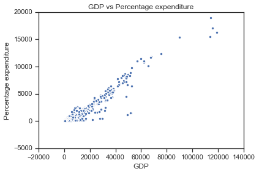

```python
plt.scatter(data['GDP'], data['percentageexpenditure'])
plt.xlabel('GDP')
plt.ylabel('Percentage expenditure')
plt.title("GDP vs Percentage expenditure")
```

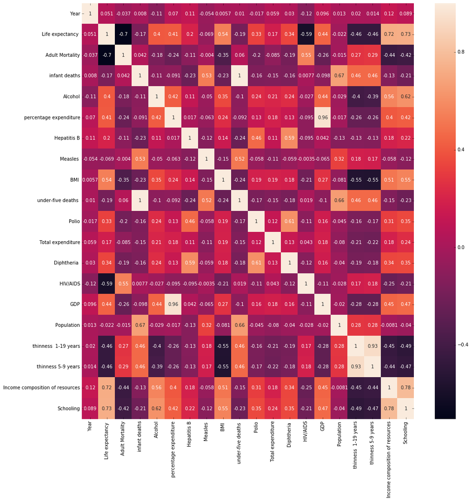

```python
Var_Corr = df1.corr()
plt.figure(figsize = (16,16))
sns.heatmap(Var_Corr, xticklabels=Var_Corr.columns, yticklabels=Var_Corr.columns, annot=True)
```

```python
#Based on the above heatmap, I chose to look at the correlation between percentage expenditure vs GDP
```

# Training our data

```python
X = df1[ 'GDP']
y = df1['percentage expenditure']
X = X.values.reshape(len(X),1)
y = y.values.reshape(len(y),1)
```

```python
from sklearn.model_selection import train_test_split
```

```python
X_train, X_test, y_train, y_test = train_test_split(X, y, test_size=0.4, random_state=101)
```

```python
from sklearn.linear_model import LinearRegression
lm = LinearRegression()
```

```python
#Let's check the size of the training and testing data
```

```python
X_train.shape, y_train.shape
```

```
((989, 1), (989, 1))
```

```python
X_test.shape, y_test.shape
```

```
((660, 1), (660, 1))
```

```python
#Next we fit the training data to a linear model
```

```python
lm.fit(X_train, y_train)
```

```
LinearRegression(copy_X=True, fit_intercept=True, n_jobs=None, normalize=False)
```

```python
#Then we use the model to predict the test data
```

```python
y_predicted = lm.predict(X_test)
```

```python
#Using Numpy we measure the accuracy of the model by using the mean square error (MSE)
```

```python
mean_sq_error = np.mean( (y_test - y_predicted) **2 )
print(mean_sq_error)
```

```
190662.96836153913
```

```python
from sklearn.metrics import mean_squared_error
print(mean_squared_error(y_true = y_test, y_pred = lm.predict(X_test)))
```

```
190662.96836153913
```

## Let's find the error on the training data

```python
print(mean_squared_error(y_true = y_train, y_pred = lm.predict(X_train)))
```

```
287539.1826950494
```

## Checking Variability: How much does the model (the x variable) account for the variability of y around its mean?

About 94% of the variability in Y can be explained using X

```python
lm.score(X_test, y_test)
```

```
0.9418230450045529
```

# Residual Histogram

```
660
```

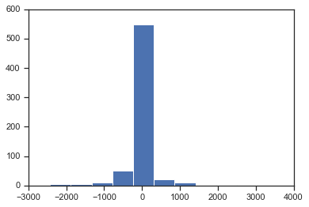

```python
#Now let's check the histogram of the residuals. Does it satisfy the assumptions
#for inference? Looking at the histogram, it does satisfy the assumption since it is a normal distribution
plt1 = plt.hist(y_test - y_predicted)
X_test.size
```

# Comparing tested and predicted values

```
<function matplotlib.pyplot.show(*args, **kw)>
```

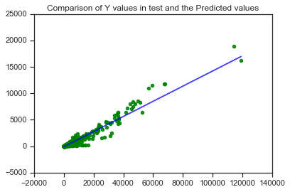

```python
plt.title('Comparison of Y values in test and the Predicted values')

plt.plot(X_test, y_predicted, color = 'blue', alpha = 0.7)

plt.scatter(X_test, y_test, color = 'green', alpha = 0.9)

plt.show
```

```python
y_test.size
```

```
660
```

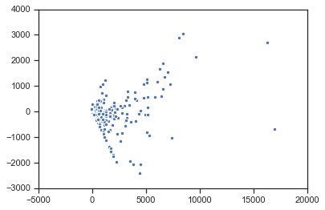

```python
plt.scatter(y_predicted, y_test - y_predicted)
```

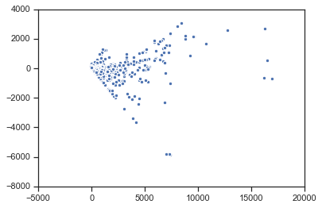

```python
#scatter plot of the predicted data
plt.scatter(lm.predict(X), y - lm.predict(X))
```

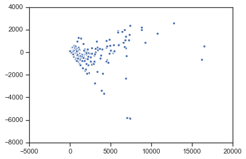

```python
#scatter plot of trained data
plt.scatter(lm.predict(X_train), y_train - lm.predict(X_train))
```

```python
print(lm.coef_)
```

```
[[0.14319289]]
```

# Coefficient Interpretation:

For every dollar increase in GDP, the percentage expenditure increases by 0.14 percent.

```python
print(lm.intercept_)
```

```
[-110.05514986]
```

# For the intercept, a specific interpretation is not needed since it would not make sense.

When GDP is 0, the percentage expenditure is -110 percent makes no sense.